# Tarea 2 TS

Federico Daverio

# Ejercicio 1

Importar la base de datos INPC como logarítmica, convertirla a serie de tiempo y graficarla (la serie comienza en enero de 1969). Descargue los datos de: https://www.inegi.org.mx/sistemas/bie/

Importamos los datos averiguando las variables presentes y formateandolos como series de tiempo mensil.

```r
INPC<- log(read_excel("./BIE_BIE20210207133327.xls", range="b1:b625",col_names = TRUE))
names(INPC) <- "INPC"
INPC1 <- xts(x =INPC , order.by = seq(as.Date("1969-01-01"), length = nrow(INPC), by = "month"))
```

Ploteamos la serie completa

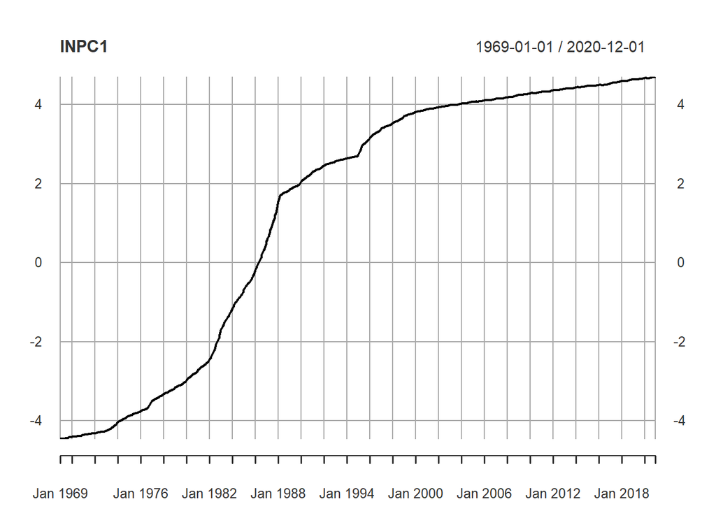

```r
plot(INPC1)
```

# Ejercicio 2

Partir la serie en 2

## Inciso A

Tomar una parte de la serie de tiempo que comience en enero 1969 y termine en Diciembre 2000, calcular sus tasas anuales y convertirla a serie de tiempo Dividimos la serie en dos partes como indicado y ploteamos las dos series separadas

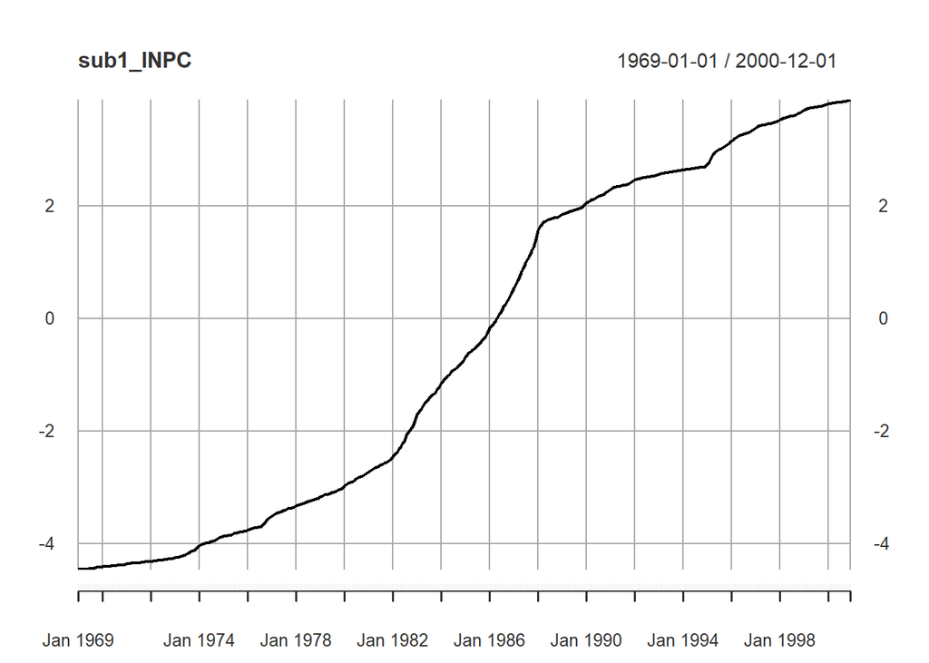

```r
sub1_INPC <- INPC1["196901/20001201"]
sub2_INPC <- INPC1["20010101/20201201"]
plot(sub1_INPC)
```

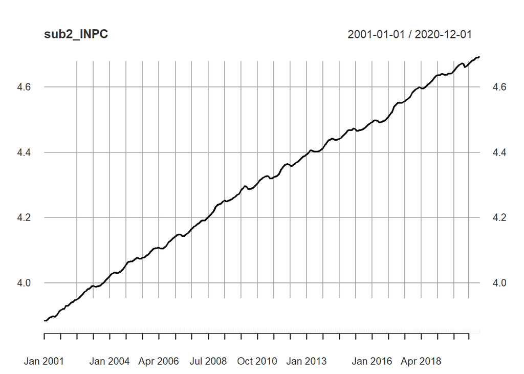

```r
plot(sub2_INPC)
```

## Inciso B

Tomar una parte de la serie de tiempo que comience en enero 2001 y termine en el año 2020, calcular sus tasas anuales y convertirla a serie de tiempo

Calculamos las tasas anuales y graficamos ambas

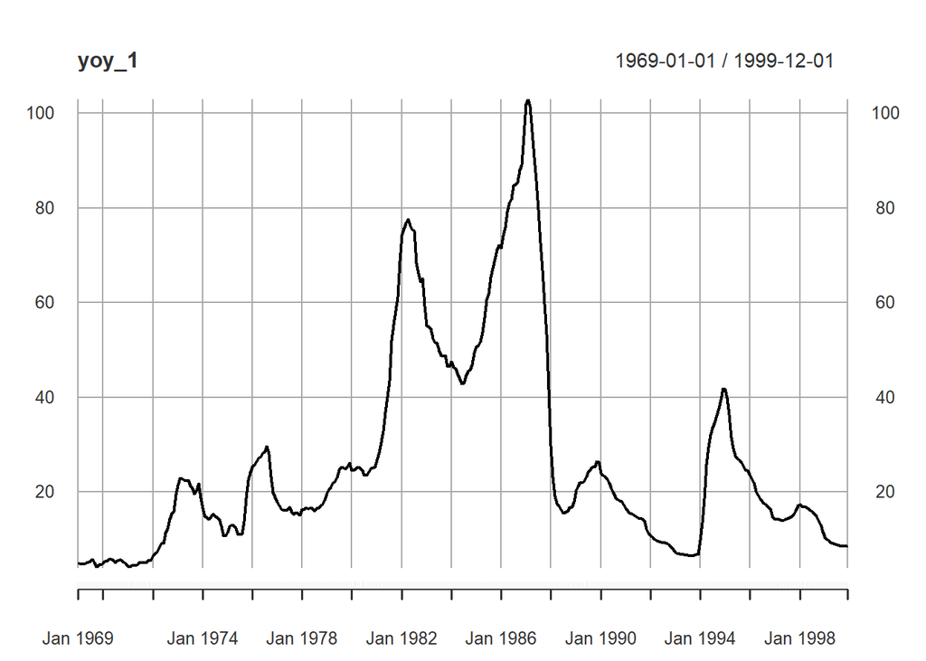

```r
yoy_1 <- (as.numeric(sub1_INPC["197001/200012"]) - as.numeric(sub1_INPC["196901/199912"]))*100
yoy_1 <- xts(x = yoy_1, order.by = seq(as.Date("1969-01-01"), length =NROW(yoy_1), by = "month"))
plot(yoy_1)
```

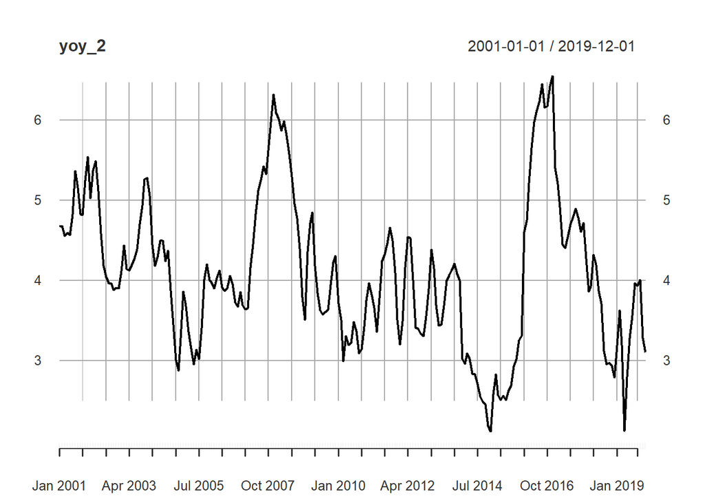

```r
yoy_2 <- (as.numeric(sub2_INPC["200201/202012"]) - as.numeric(sub2_INPC["200101/201912"]))*100
yoy_2 <- xts(x = yoy_2, order.by = seq(as.Date("2001-01-01"), length =NROW(yoy_2), by = "month"))
plot(yoy_2)
```

## Inciso C

¿Por qué deberíamos de usar la segunda serie de tiempo (Ene 2001- Jun 2020)? Justificación económica.

La segunda serie de tiempo tiene el año base y puede darnos una mayor visión con respecto a los cambios que son relativos a los ultimos años. De la grafica de la serie completa podemos notar que esta se estabiliza en los ultimos años. Esto se debe principalmente a la politica del Banco de Mexico enfocada en la definición de una tasa de inflación objetivo relativamente constante en los años. Por lo tanto también economicamente nos puede dar mayores informaciónes y capaicdad predictiva la segunda serie.

# Ejercicio 3

En un ciclo cambiar el año base de Julio 2018 a mayo 2020 (utilizando la serie de tiempo de Ene 2001-Jun 2020)

## Inciso A

Grafíquela

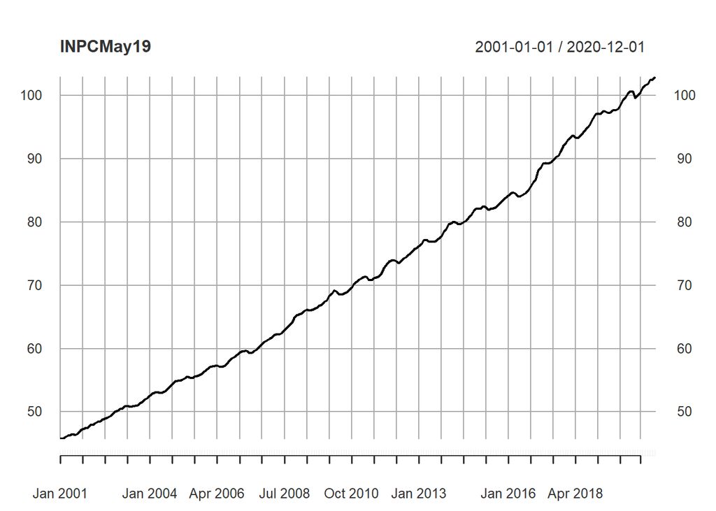

```r
INPC2<- read_excel("./BIE_BIE20210207133327.xls", range="b1:b625",col_names = TRUE)
names(INPC2) <- "INPC2"
INPC2 <- xts(x =INPC2 , order.by = seq(as.Date("1969-01-01"), length = nrow(INPC2), by = "month"))
sub_INPC2 <- INPC2["20010101/20201201"]
INPCMay19 <- (sub_INPC2/106.162)*100 #106.16200 is  May 2020 INPC
plot(INPCMay19)
```

## Inciso B

Vuelva la serie a logarítmica y calcule las tasas de crecimiento entre periodos

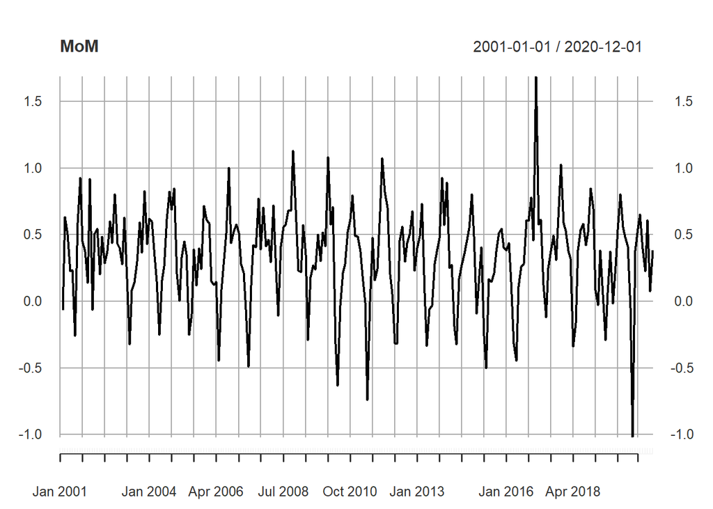

```r
INPCMay19 <-log(INPCMay19)
MoM<-(as.numeric(INPCMay19)-as.numeric(stats::lag(INPCMay19)))*100
MoM <- xts(x = MoM, order.by = seq(as.Date("2001-01-01"), length =NROW(MoM), by = "month"))
plot(MoM)
```

## Inciso C

¿Qué tan distintas serían las tasas mensuales si se calcularán con la serie año base Julio 2018 y año base mayo 2020?

No se alteran las propiedades del indicador en cuanto estamos tomando un delta, osea un cambio porcentual que no depende del año base.

## Inciso D

Exporta la xts a csv

Exportamos la base

```r
write.zoo(MoM,file="MoM.csv", sep=",")
```